# RAMYA KARANAM-ML-GRADED MICROPROJECT

### Problem Statement:

#### Refer HR_Dataset to uncover insights about possible employee attrition.

The target variable according to the problem statement is likely "Attrition," which refers to whether an employee leaves the company or not.

```python
import pyforest
import warnings
warnings.filterwarnings('ignore')
import scipy.stats as st
```

```python
# Load the dataset
data = pd.read_csv("HR_Dataset.csv")
```

```python
# Display the first few rows of the dataset
data.head()
```

|  | Age | Attrition | BusinessTravel | DailyRate | Department | DistanceFromHome | Education | EducationField | EmployeeCount | EmployeeNumber | ... | RelationshipSatisfaction | StandardHours | StockOptionLevel | TotalWorkingYears | TrainingTimesLastYear | WorkLifeBalance | YearsAtCompany | YearsInCurrentRole | YearsSinceLastPromotion | YearsWithCurrManager |
| --- | --- | --- | --- | --- | --- | --- | --- | --- | --- | --- | --- | --- | --- | --- | --- | --- | --- | --- | --- | --- | --- |
| 0 | 41 | Yes | Travel_Rarely | 1102 | Sales | 1 | 2 | Life Sciences | 1 | 1 | ... | 1 | 80 | 0 | 8 | 0 | 1 | 6 | 4 | 0 | 5 |
| 1 | 49 | No | Travel_Frequently | 279 | Research & Development | 8 | 1 | Life Sciences | 1 | 2 | ... | 4 | 80 | 1 | 10 | 3 | 3 | 10 | 7 | 1 | 7 |
| 2 | 37 | Yes | Travel_Rarely | 1373 | Research & Development | 2 | 2 | Other | 1 | 4 | ... | 2 | 80 | 0 | 7 | 3 | 3 | 0 | 0 | 0 | 0 |
| 3 | 33 | No | Travel_Frequently | 1392 | Research & Development | 3 | 4 | Life Sciences | 1 | 5 | ... | 3 | 80 | 0 | 8 | 3 | 3 | 8 | 7 | 3 | 0 |
| 4 | 27 | No | Travel_Rarely | 591 | Research & Development | 2 | 1 | Medical | 1 | 7 | ... | 4 | 80 | 1 | 6 | 3 | 3 | 2 | 2 | 2 | 2 |

5 rows × 35 columns

```python
data.shape
```

```
(917, 35)
```

```python
data.info()
```

```
<class 'pandas.core.frame.DataFrame'>
RangeIndex: 917 entries, 0 to 916
Data columns (total 35 columns):
 #   Column                    Non-Null Count  Dtype
---  ------                    --------------  -----
 0   Age                       917 non-null    int64
 1   Attrition                 917 non-null    object
 2   BusinessTravel            917 non-null    object
 3   DailyRate                 917 non-null    int64
 4   Department                917 non-null    object
 5   DistanceFromHome          917 non-null    int64
 6   Education                 917 non-null    int64
 7   EducationField            917 non-null    object
 8   EmployeeCount             917 non-null    int64
 9   EmployeeNumber            917 non-null    int64
```

[output cut: 27 more lines]

#### DATA PREPARATION

```python
data.isnull().sum()
```

```
Age                         0
Attrition                   0
BusinessTravel              0
DailyRate                   0
Department                  0
DistanceFromHome            0
Education                   0
EducationField              0
EmployeeCount               0
EmployeeNumber              0
EnvironmentSatisfaction     0
Gender                      0
HourlyRate                  0
JobInvolvement              0
JobLevel                    0
JobRole                     0
JobSatisfaction             0
MaritalStatus               0
MonthlyIncome               0
MonthlyRate                 0
NumCompaniesWorked          0
Over18                      0
OverTime                    0
PercentSalaryHike           0
PerformanceRating           0
RelationshipSatisfaction    0
StandardHours               0
StockOptionLevel            0
TotalWorkingYears           0
TrainingTimesLastYear       0
WorkLifeBalance             0
YearsAtCompany              0
YearsInCurrentRole          0
YearsSinceLastPromotion     0
YearsWithCurrManager        0
dtype: int64
```

Result : No Missing Values

```python
data.duplicated().sum()
```

```
0
```

Result: No Duplicates in the data

```python
data.dtypes
```

```
Age                          int64
Attrition                   object
BusinessTravel              object
DailyRate                    int64
Department                  object
DistanceFromHome             int64
Education                    int64
EducationField              object
EmployeeCount                int64
EmployeeNumber               int64
EnvironmentSatisfaction      int64
Gender                      object
HourlyRate                   int64
JobInvolvement               int64
JobLevel                     int64
JobRole                     object
JobSatisfaction              int64
MaritalStatus               object
MonthlyIncome                int64
MonthlyRate                  int64
NumCompaniesWorked           int64
Over18                      object
OverTime                    object
PercentSalaryHike            int64
PerformanceRating            int64
RelationshipSatisfaction     int64
StandardHours                int64
StockOptionLevel             int64
TotalWorkingYears            int64
TrainingTimesLastYear        int64
WorkLifeBalance              int64
YearsAtCompany               int64
YearsInCurrentRole           int64
YearsSinceLastPromotion      int64
YearsWithCurrManager         int64
dtype: object
```

```python
# Data Preprocessing
# Drop unnecessary columns
data.drop(['EmployeeCount', 'EmployeeNumber', 'Over18', 'StandardHours'], axis=1, inplace=True)
```

```python
data.head()
```

|  | Age | Attrition | BusinessTravel | DailyRate | Department | DistanceFromHome | Education | EducationField | EnvironmentSatisfaction | Gender | ... | PerformanceRating | RelationshipSatisfaction | StockOptionLevel | TotalWorkingYears | TrainingTimesLastYear | WorkLifeBalance | YearsAtCompany | YearsInCurrentRole | YearsSinceLastPromotion | YearsWithCurrManager |
| --- | --- | --- | --- | --- | --- | --- | --- | --- | --- | --- | --- | --- | --- | --- | --- | --- | --- | --- | --- | --- | --- |
| 0 | 41 | Yes | Travel_Rarely | 1102 | Sales | 1 | 2 | Life Sciences | 2 | Female | ... | 3 | 1 | 0 | 8 | 0 | 1 | 6 | 4 | 0 | 5 |
| 1 | 49 | No | Travel_Frequently | 279 | Research & Development | 8 | 1 | Life Sciences | 3 | Male | ... | 4 | 4 | 1 | 10 | 3 | 3 | 10 | 7 | 1 | 7 |
| 2 | 37 | Yes | Travel_Rarely | 1373 | Research & Development | 2 | 2 | Other | 4 | Male | ... | 3 | 2 | 0 | 7 | 3 | 3 | 0 | 0 | 0 | 0 |
| 3 | 33 | No | Travel_Frequently | 1392 | Research & Development | 3 | 4 | Life Sciences | 4 | Female | ... | 3 | 3 | 0 | 8 | 3 | 3 | 8 | 7 | 3 | 0 |
| 4 | 27 | No | Travel_Rarely | 591 | Research & Development | 2 | 1 | Medical | 1 | Male | ... | 3 | 4 | 1 | 6 | 3 | 3 | 2 | 2 | 2 | 2 |

5 rows × 31 columns

```python
### Outlier Analysis and Treatment
```

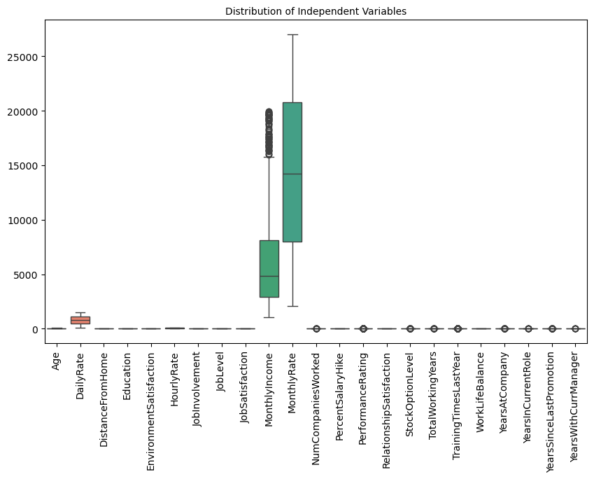

```python
# Checking for outliers
plt.figure(figsize=(10, 6))
sns.boxplot(data=data)
plt.title('Distribution of Independent Variables', fontsize = 10)
# xticks() returns the x-axis ticks
# 'rotation = vertical' rotates the x-axis labels vertically
plt.xticks(rotation = 'vertical', fontsize = 10)
plt.show()
```

Let us use the IQR method to remove the outliers.

```python
# Outlier treatment
q1 = data['MonthlyIncome'].quantile(0.25)
q3 = data['MonthlyIncome'].quantile(0.75)
iqr = q3 - q1
upper_bound = q3 + 1.5 * iqr
lower_bound = q1-1.5 * iqr
data = data[(data['MonthlyIncome'] <= upper_bound) & (data['MonthlyIncome'] >= lower_bound) ]
```

```python
# check the shape of the data
data.shape
```

```
(837, 31)
```

### Interpretation: A crude way to know whether the outliers have been removed or not is to check the dimensions of the data. From the above output, we can see that the dimensions are reduced that implies outliers are removed.

```python
# Descriptive statistics for numerical variables
numerical_stats = data.describe()
print("Descriptive statistics for numerical variables:")
numerical_stats
```

```
Descriptive statistics for numerical variables:
```

|  | Age | DailyRate | DistanceFromHome | Education | EnvironmentSatisfaction | HourlyRate | JobInvolvement | JobLevel | JobSatisfaction | MonthlyIncome | ... | PerformanceRating | RelationshipSatisfaction | StockOptionLevel | TotalWorkingYears | TrainingTimesLastYear | WorkLifeBalance | YearsAtCompany | YearsInCurrentRole | YearsSinceLastPromotion | YearsWithCurrManager |
| --- | --- | --- | --- | --- | --- | --- | --- | --- | --- | --- | --- | --- | --- | --- | --- | --- | --- | --- | --- | --- | --- |
| count | 837.000000 | 837.000000 | 837.000000 | 837.000000 | 837.000000 | 837.000000 | 837.000000 | 837.000000 | 837.000000 | 837.000000 | ... | 837.000000 | 837.000000 | 837.000000 | 837.000000 | 837.000000 | 837.000000 | 837.000000 | 837.000000 | 837.000000 | 837.000000 |
| mean | 35.967742 | 789.741935 | 9.407407 | 2.917563 | 2.724014 | 66.347670 | 2.718041 | 1.811231 | 2.696535 | 5337.475508 | ... | 3.144564 | 2.626045 | 0.824373 | 9.776583 | 2.799283 | 2.749104 | 6.347670 | 4.015532 | 1.923536 | 3.838710 |
| std | 8.596214 | 401.043278 | 8.071753 | 1.026743 | 1.099830 | 20.089805 | 0.725029 | 0.822947 | 1.108320 | 3105.168836 | ... | 0.351871 | 1.079358 | 0.877130 | 6.380032 | 1.305252 | 0.711585 | 5.067939 | 3.420806 | 2.900071 | 3.351645 |
| min | 18.000000 | 102.000000 | 1.000000 | 1.000000 | 1.000000 | 30.000000 | 1.000000 | 1.000000 | 1.000000 | 1051.000000 | ... | 3.000000 | 1.000000 | 0.000000 | 0.000000 | 0.000000 | 1.000000 | 0.000000 | 0.000000 | 0.000000 | 0.000000 |
| 25% | 30.000000 | 458.000000 | 2.000000 | 2.000000 | 2.000000 | 49.000000 | 2.000000 | 1.000000 | 2.000000 | 2814.000000 | ... | 3.000000 | 2.000000 | 0.000000 | 6.000000 | 2.000000 | 2.000000 | 3.000000 | 2.000000 | 0.000000 | 2.000000 |
| 50% | 35.000000 | 783.000000 | 8.000000 | 3.000000 | 3.000000 | 66.000000 | 3.000000 | 2.000000 | 3.000000 | 4591.000000 | ... | 3.000000 | 3.000000 | 1.000000 | 9.000000 | 3.000000 | 3.000000 | 5.000000 | 3.000000 | 1.000000 | 3.000000 |
| 75% | 41.000000 | 1142.000000 | 15.000000 | 4.000000 | 4.000000 | 84.000000 | 3.000000 | 2.000000 | 4.000000 | 6667.000000 | ... | 3.000000 | 4.000000 | 1.000000 | 12.000000 | 3.000000 | 3.000000 | 9.000000 | 7.000000 | 2.000000 | 7.000000 |
| max | 60.000000 | 1498.000000 | 29.000000 | 5.000000 | 4.000000 | 100.000000 | 4.000000 | 4.000000 | 4.000000 | 15787.000000 | ... | 4.000000 | 4.000000 | 3.000000 | 35.000000 | 6.000000 | 4.000000 | 33.000000 | 17.000000 | 15.000000 | 17.000000 |

8 rows × 23 columns

```python
data.columns
```

```
Index(['Age', 'Attrition', 'BusinessTravel', 'DailyRate', 'Department',
       'DistanceFromHome', 'Education', 'EducationField',
       'EnvironmentSatisfaction', 'Gender', 'HourlyRate', 'JobInvolvement',
       'JobLevel', 'JobRole', 'JobSatisfaction', 'MaritalStatus',
       'MonthlyIncome', 'MonthlyRate', 'NumCompaniesWorked', 'OverTime',
       'PercentSalaryHike', 'PerformanceRating', 'RelationshipSatisfaction',
       'StockOptionLevel', 'TotalWorkingYears', 'TrainingTimesLastYear',
       'WorkLifeBalance', 'YearsAtCompany', 'YearsInCurrentRole',
       'YearsSinceLastPromotion', 'YearsWithCurrManager'],
      dtype='object')
```

```python
# Descriptive statistics for categorical variables
categorical_cols = ['Attrition', 'BusinessTravel','Department','EducationField','Gender','JobRole',
                    'MaritalStatus','OverTime']
categorical_stats = {}
for col in categorical_cols:
    categorical_stats[col] = data[col].value_counts()

print("\nDescriptive statistics for categorical variables:")
for col, stats in categorical_stats.items():
    print(f"\n{col}:")
    print(stats)
```

```
Descriptive statistics for categorical variables:

Attrition:
No     687
Yes    150
Name: Attrition, dtype: int64

BusinessTravel:
Travel_Rarely        585
Travel_Frequently    163
Non-Travel            89
Name: BusinessTravel, dtype: int64

Department:
Research & Development    542
Sales                     255
Human Resources            40
Name: Department, dtype: int64

EducationField:
Life Sciences       354
Medical             254
Marketing            81
Technical Degree     80
Other                52
Human Resources      16
Name: EducationField, dtype: int64

Gender:
Male      502
Female    335
Name: Gender, dtype: int64

JobRole:
Sales Executive              203
Research Scientist           182
Laboratory Technician        162
Manufacturing Director        92
Healthcare Representative     83
Sales Representative          50
Human Resources               39
Research Director             18
Manager                        8
Name: JobRole, dtype: int64

MaritalStatus:
Married     394
Single      269
Divorced    174
Name: MaritalStatus, dtype: int64

OverTime:
No     592
Yes    245
Name: OverTime, dtype: int64
```

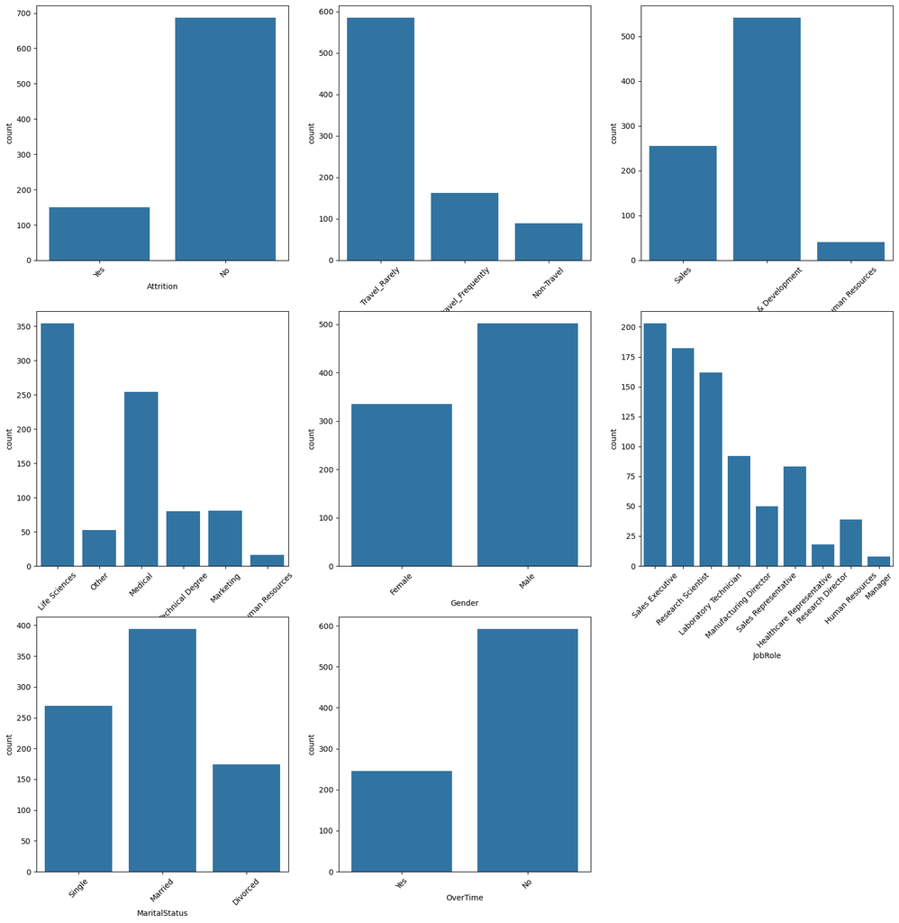

```python
# Countplot for categorical variables

plt.figure(figsize=(20,85))
plot_num=1
for i in categorical_cols:
    ax=plt.subplot(12,3,plot_num)
    sns.countplot(x=i,data=data)
    plt.xticks(rotation=45)
    plot_num+=1
plt.show()
```

#### Observations:

No Attrition are very high.

travel rarely are very high in businesstravel.

In department field Research & development plays major role.

In EducationField LifeScience first and then medical are dominating .

Male Gender is high comapared to female.

In a JobRole 'sales executive','Research Scientist' and 'Laboratory Technician' are playing a major role .

Married count high followed by single and dicorced.

No Overtime is high compared yes.

```python
data.columns
```

```
Index(['Age', 'Attrition', 'BusinessTravel', 'DailyRate', 'Department',
       'DistanceFromHome', 'Education', 'EducationField',
       'EnvironmentSatisfaction', 'Gender', 'HourlyRate', 'JobInvolvement',
       'JobLevel', 'JobRole', 'JobSatisfaction', 'MaritalStatus',
       'MonthlyIncome', 'MonthlyRate', 'NumCompaniesWorked', 'OverTime',
       'PercentSalaryHike', 'PerformanceRating', 'RelationshipSatisfaction',
       'StockOptionLevel', 'TotalWorkingYears', 'TrainingTimesLastYear',
       'WorkLifeBalance', 'YearsAtCompany', 'YearsInCurrentRole',
       'YearsSinceLastPromotion', 'YearsWithCurrManager'],
      dtype='object')
```

```python
num_cols=['Age','DailyRate','DistanceFromHome','Education','EnvironmentSatisfaction',
          'HourlyRate','JobInvolvement','JobLevel','JobSatisfaction','MonthlyIncome','MonthlyRate', 'NumCompaniesWorked',
          'PercentSalaryHike','PerformanceRating','RelationshipSatisfaction','StockOptionLevel','TotalWorkingYears','TrainingTimesLastYear',
          'WorkLifeBalance','YearsAtCompany','YearsInCurrentRole','YearsSinceLastPromotion','YearsWithCurrManager']
```

```python
len(num_cols)
```

```
23
```

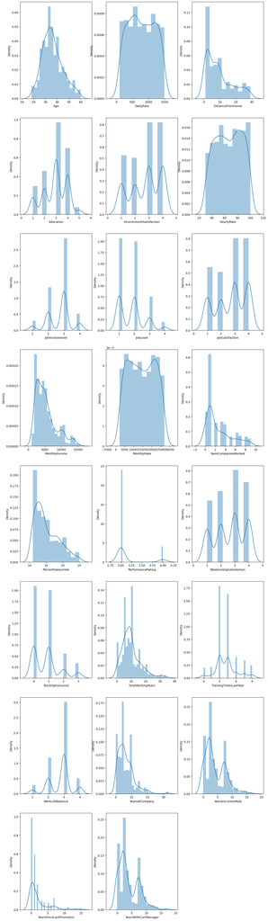

```python
# Distplot for Numerical variables
plt.figure(figsize=(15,85))
plot_num=1
for i in num_cols:
    ax=plt.subplot(12,3,plot_num)
    sns.distplot(data[i])
    plot_num+=1
plt.show()
```

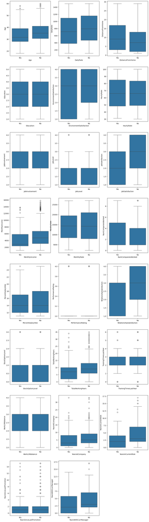

```python
# Plotting boxplot of features with respect to target variable.
plt.figure(figsize=(15,85))
plot_num=1
for i in num_cols:
    ax=plt.subplot(12,3,plot_num)
    sns.boxplot(x='Attrition',y=data[i],data=data)
    plt.xlabel(i)
    plot_num+=1
plt.show()
```

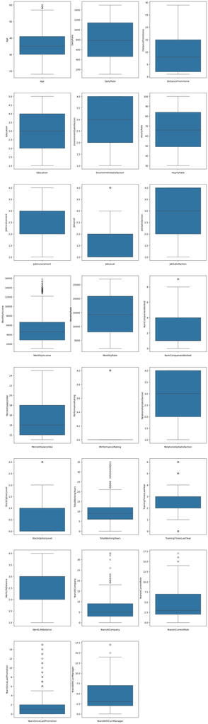

```python
# Boxplot for outliers

plt.figure(figsize=(15,85))
plot_num=1
for i in num_cols:
    ax=plt.subplot(12,3,plot_num)
    sns.boxplot(data[i])
    plt.xlabel(i)
    plot_num+=1
plt.show()
```

From the above plots variables such as 'Age','Joblevel','MonthlyIncome','NumCompaniesWorked','PerformanceRating','StockOptionLevel' 'totalWorkingYears','TrainingTimesLastYear','YearsAtCompany','YearsInCurrentRole','YearsSineLastPromotion' and 'YearsWithCurrManager' have outliers

```python
data_num = data[['Age','DailyRate','DistanceFromHome','Education','EnvironmentSatisfaction',
          'HourlyRate','JobInvolvement','JobLevel','JobSatisfaction','MonthlyIncome','MonthlyRate', 'NumCompaniesWorked',
          'PercentSalaryHike','PerformanceRating','RelationshipSatisfaction','StockOptionLevel','TotalWorkingYears','TrainingTimesLastYear',
          'WorkLifeBalance','YearsAtCompany','YearsInCurrentRole','YearsSinceLastPromotion','YearsWithCurrManager']]
```

```python
# Compute the correlation matrix
correlation_matrix = data_num.corr()

correlation_matrix
```

|  | Age | DailyRate | DistanceFromHome | Education | EnvironmentSatisfaction | HourlyRate | JobInvolvement | JobLevel | JobSatisfaction | MonthlyIncome | ... | PerformanceRating | RelationshipSatisfaction | StockOptionLevel | TotalWorkingYears | TrainingTimesLastYear | WorkLifeBalance | YearsAtCompany | YearsInCurrentRole | YearsSinceLastPromotion | YearsWithCurrManager |
| --- | --- | --- | --- | --- | --- | --- | --- | --- | --- | --- | --- | --- | --- | --- | --- | --- | --- | --- | --- | --- | --- |
| Age | 1.000000 | 0.033134 | 0.014964 | 0.230500 | -0.015113 | 0.043854 | 0.027328 | 0.425580 | 0.028727 | 0.411277 | ... | 0.006685 | 0.057099 | 0.041764 | 0.607244 | -0.026377 | -0.004258 | 0.279854 | 0.212884 | 0.184727 | 0.189387 |
| DailyRate | 0.033134 | 1.000000 | -0.022529 | -0.008650 | 0.021073 | 0.027472 | 0.037115 | -0.002594 | 0.040977 | 0.011875 | ... | -0.008636 | 0.011084 | 0.073426 | 0.017170 | 0.011283 | -0.012135 | -0.025920 | 0.022906 | -0.036737 | -0.032486 |
| DistanceFromHome | 0.014964 | -0.022529 | 1.000000 | 0.030326 | -0.020331 | 0.022302 | -0.038396 | 0.112434 | -0.030288 | 0.072939 | ... | 0.033568 | 0.004053 | 0.023972 | 0.073519 | -0.040936 | -0.032581 | 0.062063 | 0.058774 | 0.051359 | 0.038953 |
| Education | 0.230500 | -0.008650 | 0.030326 | 1.000000 | -0.036061 | 0.035258 | 0.069970 | 0.089151 | -0.025164 | 0.089230 | ... | -0.006705 | 0.006689 | 0.046330 | 0.164815 | -0.040923 | 0.043694 | 0.054939 | 0.046682 | 0.028411 | 0.049661 |
| EnvironmentSatisfaction | -0.015113 | 0.021073 | -0.020331 | -0.036061 | 1.000000 | -0.036417 | -0.024200 | 0.026953 | -0.032481 | 0.014000 | ... | -0.008054 | 0.006667 | 0.005493 | -0.010332 | -0.006971 | 0.030634 | 0.036335 | 0.060913 | 0.047754 | 0.040478 |
| HourlyRate | 0.043854 | 0.027472 | 0.022302 | 0.035258 | -0.036417 | 1.000000 | 0.068412 | -0.023230 | -0.081748 | 0.008150 | ... | 0.001004 | 0.038605 | 0.062798 | 0.030965 | -0.028948 | -0.039493 | -0.011445 | -0.008990 | -0.050788 | -0.005508 |
| JobInvolvement | 0.027328 | 0.037115 | -0.038396 | 0.069970 | -0.024200 | 0.068412 | 1.000000 | -0.031173 | 0.021409 | -0.048128 | ... | -0.032272 | 0.059225 | -0.015890 | -0.018289 | -0.016899 | 0.015739 | -0.005843 | 0.054338 | -0.016524 | 0.047716 |
| JobLevel | 0.425580 | -0.002594 | 0.112434 | 0.089151 | 0.026953 | -0.023230 | -0.031173 | 1.000000 | 0.024987 | 0.909100 | ... | -0.004787 | -0.020314 | 0.025273 | 0.688187 | -0.007476 | 0.037500 | 0.499312 | 0.410653 | 0.319225 | 0.355837 |
| JobSatisfaction | 0.028727 | 0.040977 | -0.030288 | -0.025164 | -0.032481 | -0.081748 | 0.021409 | 0.024987 | 1.000000 | 0.023461 | ... | -0.000861 | -0.030982 | 0.022629 | 0.022372 | 0.025648 | 0.012547 | 0.033500 | 0.001560 | 0.041524 | -0.000312 |
| MonthlyIncome | 0.411277 | 0.011875 | 0.072939 | 0.089230 | 0.014000 | 0.008150 | -0.048128 | 0.909100 | 0.023461 | 1.000000 | ... | -0.007972 | -0.006119 | 0.015529 | 0.681013 | -0.018932 | 0.036918 | 0.475829 | 0.395464 | 0.309194 | 0.325441 |
| MonthlyRate | 0.046363 | -0.039156 | 0.057361 | -0.019668 | 0.052568 | 0.008182 | -0.006288 | 0.069962 | -0.012463 | 0.083220 | ... | -0.003839 | 0.007202 | 0.001361 | 0.037832 | 0.069524 | 0.036583 | -0.000720 | -0.000552 | 0.020424 | -0.053927 |
| NumCompaniesWorked | 0.285703 | 0.071551 | -0.021066 | 0.127203 | 0.029154 | 0.013792 | 0.003165 | 0.103181 | -0.041262 | 0.125050 | ... | -0.046106 | 0.083900 | 0.032233 | 0.225759 | -0.062342 | -0.015060 | -0.124361 | -0.109924 | -0.064575 | -0.124040 |
| PercentSalaryHike | 0.021268 | 0.027342 | 0.066667 | -0.006492 | -0.001014 | -0.007932 | 0.000756 | -0.006094 | 0.013571 | -0.003912 | ... | 0.756627 | -0.057175 | -0.004286 | -0.001626 | -0.010199 | 0.030527 | -0.033212 | 0.004406 | -0.018448 | 0.000719 |
| PerformanceRating | 0.006685 | -0.008636 | 0.033568 | -0.006705 | -0.008054 | 0.001004 | -0.032272 | -0.004787 | -0.000861 | -0.007972 | ... | 1.000000 | -0.077955 | -0.006779 | 0.003215 | -0.014880 | 0.049485 | 0.010687 | 0.052789 | 0.026084 | 0.029937 |
| RelationshipSatisfaction | 0.057099 | 0.011084 | 0.004053 | 0.006689 | 0.006667 | 0.038605 | 0.059225 | -0.020314 | -0.030982 | -0.006119 | ... | -0.077955 | 1.000000 | -0.015125 | -0.011105 | 0.005243 | 0.058355 | -0.012941 | -0.028230 | -0.006853 | -0.019007 |
| StockOptionLevel | 0.041764 | 0.073426 | 0.023972 | 0.046330 | 0.005493 | 0.062798 | -0.015890 | 0.025273 | 0.022629 | 0.015529 | ... | -0.006779 | -0.015125 | 1.000000 | 0.021195 | 0.013054 | 0.042389 | 0.006218 | 0.042769 | 0.007411 | 0.021683 |
| TotalWorkingYears | 0.607244 | 0.017170 | 0.073519 | 0.164815 | -0.010332 | 0.030965 | -0.018289 | 0.688187 | 0.022372 | 0.681013 | ... | 0.003215 | -0.011105 | 0.021195 | 1.000000 | -0.025932 | 0.015830 | 0.660393 | 0.529383 | 0.393306 | 0.495273 |
| TrainingTimesLastYear | -0.026377 | 0.011283 | -0.040936 | -0.040923 | -0.006971 | -0.028948 | -0.016899 | -0.007476 | 0.025648 | -0.018932 | ... | -0.014880 | 0.005243 | 0.013054 | -0.025932 | 1.000000 | 0.055185 | -0.002096 | -0.000908 | 0.027225 | -0.006315 |
| WorkLifeBalance | -0.004258 | -0.012135 | -0.032581 | 0.043694 | 0.030634 | -0.039493 | 0.015739 | 0.037500 | 0.012547 | 0.036918 | ... | 0.049485 | 0.058355 | 0.042389 | 0.015830 | 0.055185 | 1.000000 | 0.031514 | 0.084159 | 0.035325 | 0.035674 |
| YearsAtCompany | 0.279854 | -0.025920 | 0.062063 | 0.054939 | 0.036335 | -0.011445 | -0.005843 | 0.499312 | 0.033500 | 0.475829 | ... | 0.010687 | -0.012941 | 0.006218 | 0.660393 | -0.002096 | 0.031514 | 1.000000 | 0.791988 | 0.589098 | 0.773997 |
| YearsInCurrentRole | 0.212884 | 0.022906 | 0.058774 | 0.046682 | 0.060913 | -0.008990 | 0.054338 | 0.410653 | 0.001560 | 0.395464 | ... | 0.052789 | -0.028230 | 0.042769 | 0.529383 | -0.000908 | 0.084159 | 0.791988 | 1.000000 | 0.524017 | 0.718006 |
| YearsSinceLastPromotion | 0.184727 | -0.036737 | 0.051359 | 0.028411 | 0.047754 | -0.050788 | -0.016524 | 0.319225 | 0.041524 | 0.309194 | ... | 0.026084 | -0.006853 | 0.007411 | 0.393306 | 0.027225 | 0.035325 | 0.589098 | 0.524017 | 1.000000 | 0.483967 |
| YearsWithCurrManager | 0.189387 | -0.032486 | 0.038953 | 0.049661 | 0.040478 | -0.005508 | 0.047716 | 0.355837 | -0.000312 | 0.325441 | ... | 0.029937 | -0.019007 | 0.021683 | 0.495273 | -0.006315 | 0.035674 | 0.773997 | 0.718006 | 0.483967 | 1.000000 |

23 rows × 23 columns

#### There is a strong positive correlation between "JobLevel" and "MonthlyIncome" (0.909) and between "TotalWorkingYears" and "YearsAtCompany" (0.660), while there is a weak negative correlation between "EnvironmentSatisfaction" and "HourlyRate" (-0.036).

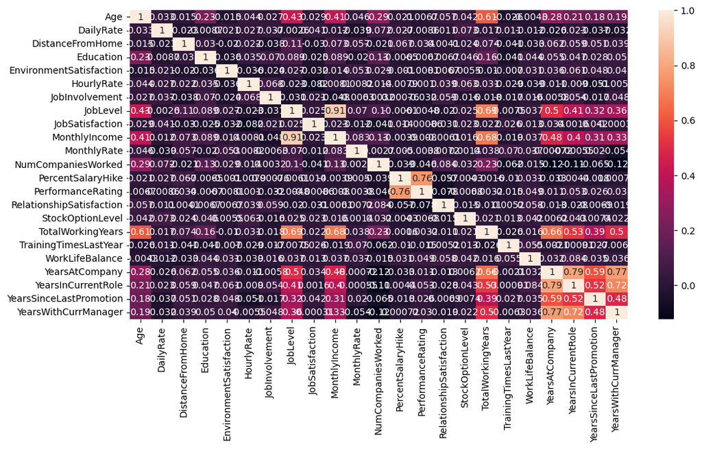

```python
# Plotting heatmap to see the correlation among numerical variables
plt.figure(figsize=(12,6))
sns.heatmap(data_num.corr(),annot=True)

plt.xticks(rotation = 'vertical', fontsize = 10)


plt.show()
```

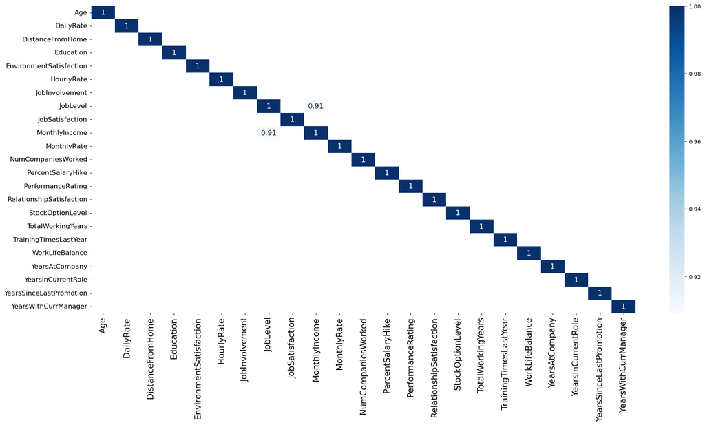

```python
# set the plot size using figure()
# pass width and height in inches to 'figsize'
plt.figure(figsize = (22,10))

# plot the heat map
# corr(): give the correlation matrix
# annot: prints the correlation values in the chart
# annot_kws: sets the font size of the annotation
sns.heatmap(data_num.corr()[np.abs(data_num.corr()) > 0.8], annot = True, annot_kws = {"size": 13}, cmap = 'Blues')

# rotate the y-axis labels
# set text size using 'fontsize'
plt.yticks(rotation = 'horizontal', fontsize = 12)
plt.xticks(fontsize = 15)

# display the plot
plt.show()
```

```python
## Plotting Attrition (Target) Category
```

```python
data["Attrition"].value_counts()
```

```
No     687
Yes    150
Name: Attrition, dtype: int64
```

```python
# Percentage of subjects with Heart Disease

Att_yes= round((data['Attrition'].value_counts()[1]/data.shape[0])*100,2)
Att_yes
```

```
17.92
```

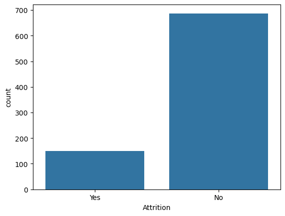

```python
sns.countplot(x="Attrition", data=data)
```

#### Result :

This indicates that the dataset is imbalanced because there is a significant difference in the number of instances between the two classes.

```python
data['Attrition'].replace({"Yes":1, "No":0}, inplace= True)
```

```python
data['Attrition'].value_counts()
```

```
0    687
1    150
Name: Attrition, dtype: int64
```

```python
Att_yes= data[data['Attrition']==1]
Att_yes.shape
```

```
(150, 31)
```

```python
# Checking no: of sub-categories for each categorical columns
for i in categorical_cols:
    print(i,":",data[i].nunique())
```

```
Attrition : 2
BusinessTravel : 3
Department : 3
EducationField : 6
Gender : 2
JobRole : 9
MaritalStatus : 3
OverTime : 2
```

### Statistical Tests

1) Plotting BusinessTravel count plot among Attrition rate

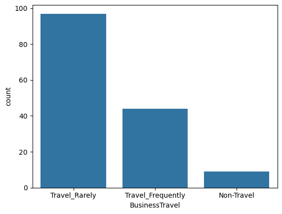

```python
sns.countplot(x="BusinessTravel", data=Att_yes)
```

```python
Att_yes["BusinessTravel"].value_counts()
```

```
Travel_Rarely        97
Travel_Frequently    44
Non-Travel            9
Name: BusinessTravel, dtype: int64
```

From the graph, Travel_rarely are more among Attrition Rates

### Hypothesis Test: Chi Square test

H0: There is no association b/w BusinessTravel & Attrition

H1: There is an association b/w BusinessTravel & Attrition

```python
pd.crosstab(data.BusinessTravel,data.Attrition,margins=True)
```

| Attrition BusinessTravel | 0 | 1 | All |
| --- | --- | --- | --- |
| Non-Travel | 80 | 9 | 89 |
| Travel_Frequently | 119 | 44 | 163 |
| Travel_Rarely | 488 | 97 | 585 |
| All | 687 | 150 | 837 |

```python
table=pd.crosstab(data.BusinessTravel,data.Attrition,margins=True)
```

```python
st.chi2_contingency(table)
```

```
Chi2ContingencyResult(statistic=13.524980665467723, pvalue=0.03541671030862943, dof=6, expected_freq=array([[ 73.05017921,  15.94982079,  89.        ],
       [133.78853047,  29.21146953, 163.        ],
       [480.16129032, 104.83870968, 585.        ],
       [687.        , 150.        , 837.        ]]))
```

### Since p value < alpha(0.05) --> reject H0

### We can conclude that there is association between BusinessTravel & Attrition.

2) Plotting Department count plot among Attrition rate

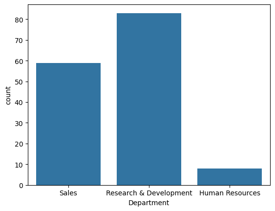

```python
sns.countplot(x="Department", data=Att_yes)
```

```python
Att_yes["Department"].value_counts()
```

```
Research & Development    83
Sales                     59
Human Resources            8
Name: Department, dtype: int64
```

From the graph,we can say that Research&Development department is more among Attrition

### Hypothesis Test: Chi Square test

H0: There is no association b/w Department & Attrition

H1: There is an association b/w Department & Attrition

```python
pd.crosstab(data.Department,data.Attrition,margins=True)
```

| Attrition Department | 0 | 1 | All |
| --- | --- | --- | --- |
| Human Resources | 32 | 8 | 40 |
| Research & Development | 459 | 83 | 542 |
| Sales | 196 | 59 | 255 |
| All | 687 | 150 | 837 |

```python
st.chi2_contingency(pd.crosstab(data.Department,data.Attrition,margins=True))
```

```
Chi2ContingencyResult(statistic=7.339434581702616, pvalue=0.29059363521569576, dof=6, expected_freq=array([[ 32.83154122,   7.16845878,  40.        ],
       [444.86738351,  97.13261649, 542.        ],
       [209.30107527,  45.69892473, 255.        ],
       [687.        , 150.        , 837.        ]]))
```

### The p-value(0.29) is greater than alpha(0.05)--> Fail to Reject H0

### We can conclude that there is No association between the Department and Attrition.

3) Plotting EducationField count plot among Attrition rate

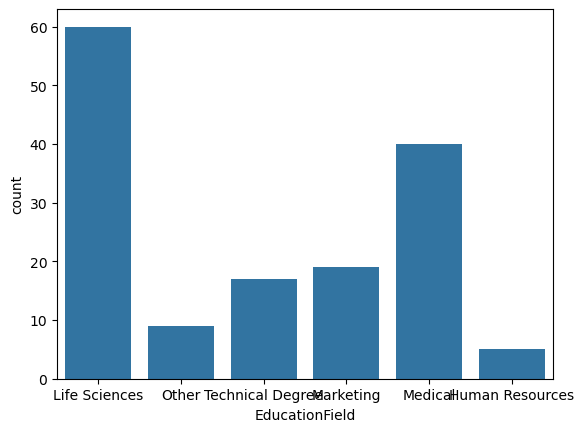

```python
sns.countplot(x="EducationField", data=Att_yes)
```

```python
Att_yes["EducationField"].value_counts()
```

```
Life Sciences       60
Medical             40
Marketing           19
Technical Degree    17
Other                9
Human Resources      5
Name: EducationField, dtype: int64
```

From the graph, we can say Life Sciences Educationfield has more Attrition

### Hypothesis Test: Chi Square test

H0: There is no association b/w EducationField & Attrition

H1: There is an association b/w EducationField & Attrition

```python
pd.crosstab(data.EducationField,data.Attrition,margins=True)
```

| Attrition EducationField | 0 | 1 | All |
| --- | --- | --- | --- |
| Human Resources | 11 | 5 | 16 |
| Life Sciences | 294 | 60 | 354 |
| Marketing | 62 | 19 | 81 |
| Medical | 214 | 40 | 254 |
| Other | 43 | 9 | 52 |
| Technical Degree | 63 | 17 | 80 |
| All | 687 | 150 | 837 |

```python
st.chi2_contingency(pd.crosstab(data.EducationField,data.Attrition,margins=True))
```

```
Chi2ContingencyResult(statistic=5.278681190183507, pvalue=0.9480171567804692, dof=12, expected_freq=array([[ 13.13261649,   2.86738351,  16.        ],
       [290.55913978,  63.44086022, 354.        ],
       [ 66.48387097,  14.51612903,  81.        ],
       [208.48028674,  45.51971326, 254.        ],
       [ 42.68100358,   9.31899642,  52.        ],
       [ 65.66308244,  14.33691756,  80.        ],
       [687.        , 150.        , 837.        ]]))
```

### The p-value(0.94) is greater than alpha(0.05)--> Fail to Reject H0

### We can conclude that there is No association between the EducationField and Attrition.

4)Plotting Gender count plot among Attrition rate

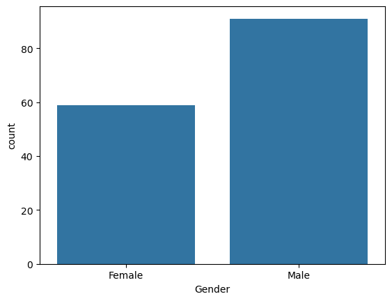

```python
sns.countplot(x="Gender", data=Att_yes)
```

```python
Att_yes["Gender"].value_counts()
```

```
Male      91
Female    59
Name: Gender, dtype: int64
```

From the graph, Male count is more among Attrition.

### Hypothesis Test:

Test whether the Attrition proportion is higher for Male

### One Sample Test of proportion @ 5% significance level

H0: Attrition Proportion of P_male <= 0.5

H1: Attrition Proportion of P_male > 0.5

```python
pd.crosstab(data.Gender,data.Attrition,margins=True)
```

| Attrition Gender | 0 | 1 | All |
| --- | --- | --- | --- |
| Female | 276 | 59 | 335 |
| Male | 411 | 91 | 502 |
| All | 687 | 150 | 837 |

```python
P=0.5
x= 91
n= 150
```

```python
from statsmodels.stats.proportion import proportions_ztest
```

```python
proportions_ztest(x,n,0.5,alternative='larger')
```

```
(2.6743541022150144, 0.0037436673576119214)
```

### Since p value(0.003) < alpha(0.05) --> reject H0

5) Plotting JobRole count plot among Attrition rate

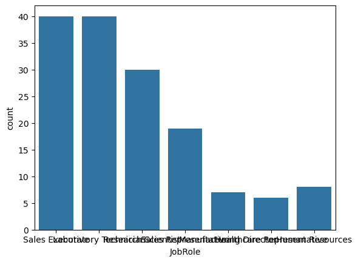

```python
sns.countplot(x="JobRole", data=Att_yes)
```

```python
Att_yes['JobRole'].value_counts()
```

```
Sales Executive              40
Laboratory Technician        40
Research Scientist           30
Sales Representative         19
Human Resources               8
Manufacturing Director        7
Healthcare Representative     6
Name: JobRole, dtype: int64
```

### Hypothesis Test: Chi Square test

H0: There is no association b/w JobRole & Attrition

H1: There is an association b/w JobRole & Attrition

```python
pd.crosstab(data.JobRole,data.Attrition,margins=True)
```

| Attrition JobRole | 0 | 1 | All |
| --- | --- | --- | --- |
| Healthcare Representative | 77 | 6 | 83 |
| Human Resources | 31 | 8 | 39 |
| Laboratory Technician | 122 | 40 | 162 |
| Manager | 8 | 0 | 8 |
| Manufacturing Director | 85 | 7 | 92 |
| Research Director | 18 | 0 | 18 |
| Research Scientist | 152 | 30 | 182 |
| Sales Executive | 163 | 40 | 203 |
| Sales Representative | 31 | 19 | 50 |
| All | 687 | 150 | 837 |

```python
st.chi2_contingency(pd.crosstab(data.JobRole,data.Attrition,margins=True))
```

```
Chi2ContingencyResult(statistic=38.403964801559155, pvalue=0.003423549928403921, dof=18, expected_freq=array([[ 68.12544803,  14.87455197,  83.        ],
       [ 32.01075269,   6.98924731,  39.        ],
       [132.96774194,  29.03225806, 162.        ],
       [  6.56630824,   1.43369176,   8.        ],
       [ 75.5125448 ,  16.4874552 ,  92.        ],
       [ 14.77419355,   3.22580645,  18.        ],
       [149.38351254,  32.61648746, 182.        ],
       [166.62007168,  36.37992832, 203.        ],
       [ 41.03942652,   8.96057348,  50.        ],
       [687.        , 150.        , 837.        ]]))
```

### The p-value(0.003) is less than alpha(0.05)--> Reject H0

### We can conclude that there is an association between the JobRole and Attrition.

6) Plotting MaritalStatus count plot among Attrition rate

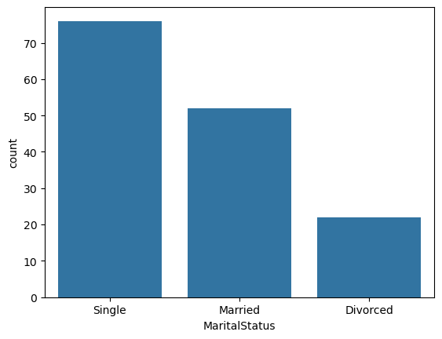

```python
sns.countplot(x="MaritalStatus", data=Att_yes)
```

```python
Att_yes['MaritalStatus'].value_counts()
```

```
Single      76
Married     52
Divorced    22
Name: MaritalStatus, dtype: int64
```

From the graph, attrition is more in single foll0wed by married.

### Hypothesis Test: Chi Square test

H0: There is no association b/w MaritalStatus & Attrition

H1: There is an association b/w MaritalStatus & Attrition

```python
pd.crosstab(data.MaritalStatus,data.Attrition,margins=True)
```

| Attrition MaritalStatus | 0 | 1 | All |
| --- | --- | --- | --- |
| Divorced | 152 | 22 | 174 |
| Married | 342 | 52 | 394 |
| Single | 193 | 76 | 269 |
| All | 687 | 150 | 837 |

```python
st.chi2_contingency(pd.crosstab(data.MaritalStatus,data.Attrition,margins=True))
```

```
Chi2ContingencyResult(statistic=28.79064539942746, pvalue=6.664489251514157e-05, dof=6, expected_freq=array([[142.8172043,  31.1827957, 174.       ],
       [323.390681 ,  70.609319 , 394.       ],
       [220.7921147,  48.2078853, 269.       ],
       [687.       , 150.       , 837.       ]]))
```

### The p-value(close to 0) is less than alpha(0.05)--> Reject H0

### We can conclude that there is an association between the MaritalStatus and Attrition.

7)Plotting OverTime count plot among Attrition rate

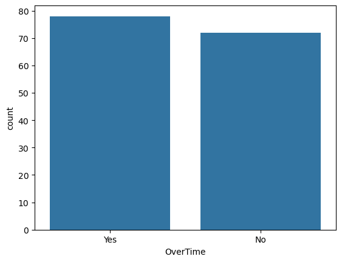

```python
sns.countplot(x="OverTime", data=Att_yes)
```

```python
Att_yes['OverTime'].value_counts()
```

```
Yes    78
No     72
Name: OverTime, dtype: int64
```

From the graph, we can see only overtime is little more on attrition

### Hypothesis Test:

One Sample Test of proportion @ 5% significance level

H0: Attrition Proportion of P_overtime <= 0.5

H1: Attrition Proportion of P_overtime > 0.5

```python
pd.crosstab(data.OverTime,data.Attrition,margins=True)
```

| Attrition OverTime | 0 | 1 | All |
| --- | --- | --- | --- |
| No | 520 | 72 | 592 |
| Yes | 167 | 78 | 245 |
| All | 687 | 150 | 837 |

```python
P=0.5
x= 78
n= 150
```

```python
proportions_ztest(x,n,0.5,alternative='larger')
```

```
(0.4902903378454605, 0.3119642316042621)
```

### Encoding and Scaling

```python
data_at= data.copy()
```

```python
data_at.info()
```

```
<class 'pandas.core.frame.DataFrame'>
Int64Index: 837 entries, 0 to 916
Data columns (total 31 columns):
 #   Column                    Non-Null Count  Dtype
---  ------                    --------------  -----
 0   Age                       837 non-null    int64
 1   Attrition                 837 non-null    int64
 2   BusinessTravel            837 non-null    object
 3   DailyRate                 837 non-null    int64
 4   Department                837 non-null    object
 5   DistanceFromHome          837 non-null    int64
 6   Education                 837 non-null    int64
 7   EducationField            837 non-null    object
 8   EnvironmentSatisfaction   837 non-null    int64
 9   Gender                    837 non-null    object
```

[output cut: 23 more lines]

```python
X= data_at.drop("Attrition", axis=1)
```

```python
X.head()
```

|  | Age | BusinessTravel | DailyRate | Department | DistanceFromHome | Education | EducationField | EnvironmentSatisfaction | Gender | HourlyRate | ... | PerformanceRating | RelationshipSatisfaction | StockOptionLevel | TotalWorkingYears | TrainingTimesLastYear | WorkLifeBalance | YearsAtCompany | YearsInCurrentRole | YearsSinceLastPromotion | YearsWithCurrManager |
| --- | --- | --- | --- | --- | --- | --- | --- | --- | --- | --- | --- | --- | --- | --- | --- | --- | --- | --- | --- | --- | --- |
| 0 | 41 | Travel_Rarely | 1102 | Sales | 1 | 2 | Life Sciences | 2 | Female | 94 | ... | 3 | 1 | 0 | 8 | 0 | 1 | 6 | 4 | 0 | 5 |
| 1 | 49 | Travel_Frequently | 279 | Research & Development | 8 | 1 | Life Sciences | 3 | Male | 61 | ... | 4 | 4 | 1 | 10 | 3 | 3 | 10 | 7 | 1 | 7 |
| 2 | 37 | Travel_Rarely | 1373 | Research & Development | 2 | 2 | Other | 4 | Male | 92 | ... | 3 | 2 | 0 | 7 | 3 | 3 | 0 | 0 | 0 | 0 |
| 3 | 33 | Travel_Frequently | 1392 | Research & Development | 3 | 4 | Life Sciences | 4 | Female | 56 | ... | 3 | 3 | 0 | 8 | 3 | 3 | 8 | 7 | 3 | 0 |
| 4 | 27 | Travel_Rarely | 591 | Research & Development | 2 | 1 | Medical | 1 | Male | 40 | ... | 3 | 4 | 1 | 6 | 3 | 3 | 2 | 2 | 2 | 2 |

5 rows × 30 columns

```python
X.shape
```

```
(837, 30)
```

```python
y=data_at['Attrition']
```

```python
y.head()
```

```
0    1
1    0
2    1
3    0
4    0
Name: Attrition, dtype: int64
```

```python
# Encoding

X = pd.get_dummies(X,drop_first=True)
X.head()
```

|  | Age | DailyRate | DistanceFromHome | Education | EnvironmentSatisfaction | HourlyRate | JobInvolvement | JobLevel | JobSatisfaction | MonthlyIncome | ... | JobRole_Laboratory Technician | JobRole_Manager | JobRole_Manufacturing Director | JobRole_Research Director | JobRole_Research Scientist | JobRole_Sales Executive | JobRole_Sales Representative | MaritalStatus_Married | MaritalStatus_Single | OverTime_Yes |
| --- | --- | --- | --- | --- | --- | --- | --- | --- | --- | --- | --- | --- | --- | --- | --- | --- | --- | --- | --- | --- | --- |
| 0 | 41 | 1102 | 1 | 2 | 2 | 94 | 3 | 2 | 4 | 5993 | ... | 0 | 0 | 0 | 0 | 0 | 1 | 0 | 0 | 1 | 1 |
| 1 | 49 | 279 | 8 | 1 | 3 | 61 | 2 | 2 | 2 | 5130 | ... | 0 | 0 | 0 | 0 | 1 | 0 | 0 | 1 | 0 | 0 |
| 2 | 37 | 1373 | 2 | 2 | 4 | 92 | 2 | 1 | 3 | 2090 | ... | 1 | 0 | 0 | 0 | 0 | 0 | 0 | 0 | 1 | 1 |
| 3 | 33 | 1392 | 3 | 4 | 4 | 56 | 3 | 1 | 3 | 2909 | ... | 0 | 0 | 0 | 0 | 1 | 0 | 0 | 1 | 0 | 1 |
| 4 | 27 | 591 | 2 | 1 | 1 | 40 | 3 | 1 | 2 | 3468 | ... | 1 | 0 | 0 | 0 | 0 | 0 | 0 | 1 | 0 | 0 |

5 rows × 44 columns

```python
#Scaling

from sklearn.preprocessing import StandardScaler
sc= StandardScaler()

for i in X.columns:
    X[i]= sc.fit_transform(X[i].values.reshape(-1,1))
```

```python
X.head()
```

|  | Age | DailyRate | DistanceFromHome | Education | EnvironmentSatisfaction | HourlyRate | JobInvolvement | JobLevel | JobSatisfaction | MonthlyIncome | ... | JobRole_Laboratory Technician | JobRole_Manager | JobRole_Manufacturing Director | JobRole_Research Director | JobRole_Research Scientist | JobRole_Sales Executive | JobRole_Sales Representative | MaritalStatus_Married | MaritalStatus_Single | OverTime_Yes |
| --- | --- | --- | --- | --- | --- | --- | --- | --- | --- | --- | --- | --- | --- | --- | --- | --- | --- | --- | --- | --- | --- |
| 0 | 0.585754 | 0.779080 | -1.042207 | -0.894198 | -0.658690 | 1.377259 | 0.389126 | 0.229519 | 1.176776 | 0.211234 | ... | -0.489898 | -0.098235 | -0.351411 | -0.14825 | -0.527127 | 1.767244 | -0.252056 | -0.943075 | 1.453108 | 1.554454 |
| 1 | 1.516953 | -1.274295 | -0.174466 | -1.868734 | 0.251085 | -0.266347 | -0.990953 | 0.229519 | -0.628836 | -0.066856 | ... | -0.489898 | -0.098235 | -0.351411 | -0.14825 | 1.897077 | -0.565853 | -0.252056 | 1.060361 | -0.688180 | -0.643313 |
| 2 | 0.120155 | 1.455221 | -0.918244 | -0.894198 | 1.160860 | 1.277646 | -0.990953 | -0.986352 | 0.273970 | -1.046454 | ... | 2.041241 | -0.098235 | -0.351411 | -0.14825 | -0.527127 | -0.565853 | -0.252056 | -0.943075 | 1.453108 | 1.554454 |
| 3 | -0.345445 | 1.502626 | -0.794281 | 1.054874 | 1.160860 | -0.515379 | 0.389126 | -0.986352 | 0.273970 | -0.782543 | ... | -0.489898 | -0.098235 | -0.351411 | -0.14825 | 1.897077 | -0.565853 | -0.252056 | 1.060361 | -0.688180 | 1.554454 |
| 4 | -1.043844 | -0.495859 | -0.918244 | -1.868734 | -1.568465 | -1.312279 | 0.389126 | -0.986352 | -0.628836 | -0.602413 | ... | 2.041241 | -0.098235 | -0.351411 | -0.14825 | -0.527127 | -0.565853 | -0.252056 | 1.060361 | -0.688180 | -0.643313 |

5 rows × 44 columns

## Model Building

### 1) Logistic Regression without SMOTE:

```python
from sklearn.model_selection import train_test_split
```

```python
xtrain,xtest,ytrain,ytest= train_test_split(X,y, test_size=0.2,random_state=10, stratify=y)
```

```python
print("xtrain shape: ", xtrain.shape)
print("xtest shape: ", xtest.shape)
print("ytrain shape: ", ytrain.shape)
print("ytest shape: ", ytest.shape)
```

```
xtrain shape:  (669, 44)
xtest shape:  (168, 44)
ytrain shape:  (669,)
ytest shape:  (168,)
```

```python
from sklearn.linear_model import LogisticRegression
```

```python
log_model= LogisticRegression()
log_model.fit(xtrain,ytrain)
```

```
LogisticRegression()
```

```python
prob_pred_y1 = log_model.predict_proba(xtest)
```

```python
pred_y1 = log_model.predict(xtest)
pred_y1
```

```
array([0, 0, 0, 0, 0, 0, 1, 0, 0, 0, 0, 0, 0, 0, 0, 0, 0, 0, 0, 0, 0, 0,
       1, 0, 0, 1, 0, 0, 0, 0, 0, 0, 1, 0, 0, 0, 0, 0, 0, 0, 0, 0, 0, 1,
       0, 0, 0, 0, 0, 0, 0, 0, 0, 0, 0, 0, 0, 0, 0, 0, 0, 0, 0, 0, 0, 0,
       0, 0, 0, 0, 0, 0, 0, 0, 1, 0, 0, 0, 1, 1, 0, 0, 0, 0, 0, 0, 0, 0,
       0, 0, 1, 0, 0, 0, 0, 0, 0, 0, 0, 0, 0, 0, 0, 0, 0, 0, 0, 0, 0, 0,
       0, 0, 0, 0, 0, 0, 1, 0, 0, 0, 0, 1, 0, 0, 0, 0, 0, 0, 0, 0, 0, 0,
       0, 0, 0, 0, 0, 0, 0, 0, 0, 0, 0, 0, 0, 0, 0, 0, 1, 0, 0, 0, 0, 0,
       0, 0, 0, 0, 0, 0, 0, 0, 0, 0, 0, 0, 1, 0], dtype=int64)
```

```python
from sklearn.metrics import plot_roc_curve, recall_score
from sklearn.metrics import plot_confusion_matrix,accuracy_score,precision_score,f1_score,roc_auc_score,classification_report,confusion_matrix
```

```python
print(classification_report(ytest,pred_y1))
```

```
              precision    recall  f1-score   support

           0       0.86      0.96      0.91       138
           1       0.62      0.27      0.37        30

    accuracy                           0.84       168
   macro avg       0.74      0.62      0.64       168
weighted avg       0.81      0.84      0.81       168
```

The model performs better in predicting class 0 (majority class) than class 1 (minority class), which is expected given the class imbalance. The model has high precision and recall for class 0 but lower precision and recall for class 1. Further tuning or using techniques like SMOTE may help improve the model's performance, especially for the minority class.

```
<sklearn.metrics._plot.confusion_matrix.ConfusionMatrixDisplay at 0x1febff49690>
```

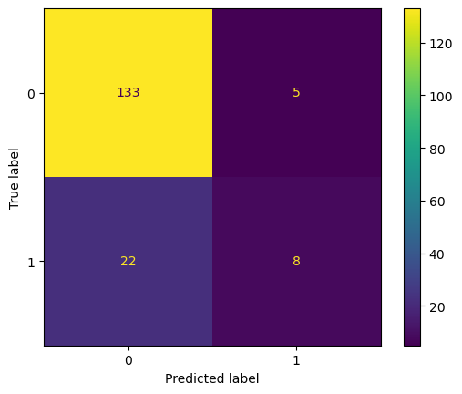

```python
plot_confusion_matrix(log_model, xtest, ytest)
```

True Positives (TP): The bottom right cell with the number 8 indicates true positives. These are instances that were correctly identified as class 1 (positive).

True Negatives (TN): The top left cell with the number 133 represents true negatives. These are instances that were correctly identified as class 0 (negative).

False Positives (FP): The top right cell with the number 5 indicates false positives. These are instances that were incorrectly predicted as class 1 (positive) when they actually belong to class 0 (negative).

False Negatives (FN): The bottom left cell with the number 22 represents false negatives. These are instances that were incorrectly predicted as class 0 (negative) when they actually belong to class 1 (positive).

```
<sklearn.metrics._plot.roc_curve.RocCurveDisplay at 0x1febebf2e90>
```

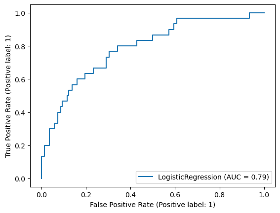

```python
plot_roc_curve(log_model, xtest, ytest)
```

The blue line in the plot represents the ROC curve for the Logistic Regression model.

As the threshold for classification changes, the model’s TPR and FPR vary.

The closer the curve is to the top-left corner, the better the model’s performance.

The AUC value of 0.79 indicates that the model has a good balance between true positives and false positives.

```python
features = X.columns
```

```python
#Feature importance
importance1 = log_model.coef_[0]
```

```python
feature_imp1 = pd.DataFrame({"Variable": features, "Coefficient": importance1 } ).round(decimals=2).sort_values("Coefficient", ascending=False).style.bar(color= ['red', 'green'])
```

```python
feature_imp1
```

|  | Variable | Coefficient |
| --- | --- | --- |
| 21 | YearsSinceLastPromotion | 0.850000 |
| 43 | OverTime_Yes | 0.840000 |
| 23 | BusinessTravel_Travel_Frequently | 0.740000 |
| 42 | MaritalStatus_Single | 0.650000 |
| 11 | NumCompaniesWorked | 0.520000 |
| 34 | JobRole_Laboratory Technician | 0.510000 |
| 24 | BusinessTravel_Travel_Rarely | 0.400000 |
| 2 | DistanceFromHome | 0.360000 |
| 19 | YearsAtCompany | 0.280000 |
| 40 | JobRole_Sales Representative | 0.270000 |
| 41 | MaritalStatus_Married | 0.180000 |
| 26 | Department_Sales | 0.180000 |
| 33 | JobRole_Human Resources | 0.160000 |
| 5 | HourlyRate | 0.150000 |
| 12 | PercentSalaryHike | 0.120000 |
| 38 | JobRole_Research Scientist | 0.120000 |
| 13 | PerformanceRating | 0.090000 |
| 39 | JobRole_Sales Executive | 0.080000 |
| 32 | Gender_Male | 0.070000 |
| 31 | EducationField_Technical Degree | 0.040000 |
| 7 | JobLevel | 0.020000 |
| 1 | DailyRate | 0.010000 |
| 9 | MonthlyIncome | -0.000000 |
| 15 | StockOptionLevel | -0.050000 |
| 3 | Education | -0.060000 |
| 36 | JobRole_Manufacturing Director | -0.080000 |
| 30 | EducationField_Other | -0.150000 |
| 10 | MonthlyRate | -0.150000 |
| 0 | Age | -0.210000 |
| 28 | EducationField_Marketing | -0.230000 |
| 4 | EnvironmentSatisfaction | -0.240000 |
| 25 | Department_Research & Development | -0.250000 |
| 6 | JobInvolvement | -0.250000 |
| 18 | WorkLifeBalance | -0.260000 |
| 35 | JobRole_Manager | -0.280000 |
| 29 | EducationField_Medical | -0.320000 |
| 22 | YearsWithCurrManager | -0.340000 |
| 37 | JobRole_Research Director | -0.350000 |
| 27 | EducationField_Life Sciences | -0.370000 |
| 17 | TrainingTimesLastYear | -0.390000 |
| 14 | RelationshipSatisfaction | -0.390000 |
| 16 | TotalWorkingYears | -0.440000 |
| 8 | JobSatisfaction | -0.540000 |
| 20 | YearsInCurrentRole | -0.630000 |

The variables with the highest absolute coefficients:

[output not shown]

### 2) Logistic Regression after SMOTE:

```python
from imblearn.over_sampling import SMOTE
```

```python
sm = SMOTE(random_state=10)
```

```python
# Before smote
print(f'Count of minority class records before upsampling: {xtrain[ytrain==1].shape[0]}')
print(f'Count of existing Majority class records: {xtrain[ytrain==0].shape[0]}')
```

```
Count of minority class records before upsampling: 120
Count of existing Majority class records: 549
```

```python
xtrain_smote, ytrain_smote = sm.fit_resample(xtrain,ytrain)
```

```python
# After smote
print(f'Count of minority class(class 1) records after SMOTE : {xtrain_smote[ytrain_smote==1].shape[0]}')
print(f'Count of existing Majority class(class 0) records: {xtrain_smote[ytrain_smote==0].shape[0]}')
```

```
Count of minority class(class 1) records after SMOTE : 549
Count of existing Majority class(class 0) records: 549
```

```python
ytrain_smote.value_counts()
```

```
0    549
1    549
Name: Attrition, dtype: int64
```

```python
log_model2= LogisticRegression()
log_model2.fit(xtrain_smote, ytrain_smote)
```

```
LogisticRegression()
```

```python
prob_pred_y2 = log_model2.predict_proba(xtest)
pred_y2 = log_model2.predict(xtest)
pred_y2
```

```
array([1, 0, 0, 0, 0, 0, 1, 0, 0, 0, 0, 0, 0, 0, 0, 0, 0, 0, 0, 0, 0, 0,
       1, 1, 1, 1, 1, 1, 0, 1, 0, 0, 1, 0, 1, 0, 0, 0, 0, 0, 0, 0, 0, 1,
       0, 1, 0, 0, 0, 0, 0, 0, 0, 0, 0, 1, 1, 0, 0, 0, 1, 0, 0, 0, 1, 0,
       0, 1, 0, 0, 0, 0, 0, 0, 1, 0, 0, 0, 1, 1, 0, 1, 0, 0, 0, 0, 1, 0,
       0, 0, 1, 0, 1, 0, 0, 0, 0, 0, 0, 0, 0, 1, 0, 0, 1, 0, 0, 0, 1, 0,
       0, 0, 0, 0, 0, 0, 1, 1, 0, 0, 0, 1, 0, 0, 0, 0, 0, 1, 0, 1, 0, 0,
       0, 1, 1, 0, 1, 0, 0, 0, 0, 0, 0, 1, 0, 0, 0, 0, 1, 1, 0, 1, 0, 1,
       0, 0, 1, 0, 1, 0, 0, 1, 0, 0, 0, 0, 1, 0], dtype=int64)
```

```python
print(classification_report(ytest,pred_y2))
```

```
              precision    recall  f1-score   support

           0       0.90      0.80      0.85       138
           1       0.40      0.60      0.48        30

    accuracy                           0.77       168
   macro avg       0.65      0.70      0.67       168
weighted avg       0.81      0.77      0.78       168
```

The model shows reasonably good performance for class 0 (non-attrition), it struggles with class 1 (attrition), particularly in terms of precision and recall. This suggests that the model may need further tuning or the use of different techniques to better predict instances of attrition.

```
<sklearn.metrics._plot.confusion_matrix.ConfusionMatrixDisplay at 0x1feb44841c0>
```

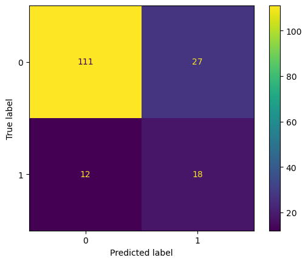

```python
plot_confusion_matrix(log_model2, xtest, ytest)
```

True Positives (TP): The bottom right cell with the number 18 indicates true positives. These are instances that were correctly identified as class 1 (positive).

True Negatives (TN): The top left cell with the number 111 represents true negatives. These are instances that were correctly identified as class 0 (negative).

False Positives (FP): The top right cell with the number 27 indicates false positives. These are instances that were incorrectly predicted as class 1 (positive) when they actually belong to class 0 (negative).

False Negatives (FN): The bottom left cell with the number 12 represents false negatives. These are instances that were incorrectly predicted as class 0 (negative) when they actually belong to class 1 (positive).

```
<sklearn.metrics._plot.roc_curve.RocCurveDisplay at 0x1fec1631d50>
```

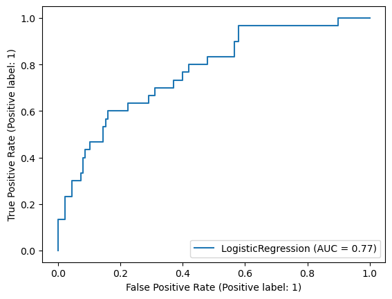

```python
plot_roc_curve(log_model2, xtest, ytest)
```

The AUC value of 0.77 indicates that the model has a good balance between true positives and false positives.

```python
#Feature importance
importance2 = log_model2.coef_[0]
```

```python
feature_imp2 = pd.DataFrame({"Variable": features, "Coefficient": importance2 } ).round(decimals=2).sort_values("Coefficient", ascending=False).style.bar(color= ['red', 'green'])
```

```python
feature_imp2
```

|  | Variable | Coefficient |
| --- | --- | --- |
| 23 | BusinessTravel_Travel_Frequently | 0.990000 |
| 21 | YearsSinceLastPromotion | 0.970000 |
| 42 | MaritalStatus_Single | 0.900000 |
| 43 | OverTime_Yes | 0.900000 |
| 24 | BusinessTravel_Travel_Rarely | 0.710000 |
| 34 | JobRole_Laboratory Technician | 0.660000 |
| 11 | NumCompaniesWorked | 0.580000 |
| 2 | DistanceFromHome | 0.360000 |
| 40 | JobRole_Sales Representative | 0.340000 |
| 19 | YearsAtCompany | 0.290000 |
| 41 | MaritalStatus_Married | 0.250000 |
| 26 | Department_Sales | 0.200000 |
| 33 | JobRole_Human Resources | 0.180000 |
| 9 | MonthlyIncome | 0.180000 |
| 13 | PerformanceRating | 0.170000 |
| 12 | PercentSalaryHike | 0.160000 |
| 5 | HourlyRate | 0.140000 |
| 7 | JobLevel | 0.140000 |
| 38 | JobRole_Research Scientist | 0.140000 |
| 32 | Gender_Male | 0.100000 |
| 39 | JobRole_Sales Executive | 0.080000 |
| 0 | Age | 0.010000 |
| 3 | Education | 0.010000 |
| 15 | StockOptionLevel | -0.030000 |
| 31 | EducationField_Technical Degree | -0.060000 |
| 1 | DailyRate | -0.070000 |
| 36 | JobRole_Manufacturing Director | -0.110000 |
| 4 | EnvironmentSatisfaction | -0.200000 |
| 10 | MonthlyRate | -0.210000 |
| 6 | JobInvolvement | -0.240000 |
| 22 | YearsWithCurrManager | -0.260000 |
| 18 | WorkLifeBalance | -0.270000 |
| 25 | Department_Research & Development | -0.280000 |
| 29 | EducationField_Medical | -0.330000 |
| 30 | EducationField_Other | -0.340000 |
| 28 | EducationField_Marketing | -0.390000 |
| 14 | RelationshipSatisfaction | -0.420000 |
| 35 | JobRole_Manager | -0.440000 |
| 27 | EducationField_Life Sciences | -0.480000 |
| 17 | TrainingTimesLastYear | -0.510000 |
| 37 | JobRole_Research Director | -0.560000 |
| 20 | YearsInCurrentRole | -0.670000 |
| 8 | JobSatisfaction | -0.730000 |
| 16 | TotalWorkingYears | -0.790000 |

The variables with the highest absolute coefficients:

[output not shown]

### 3) KNN Classifier without SMOTE:

```python
from sklearn.neighbors import KNeighborsClassifier
```

```python
knn = KNeighborsClassifier()
```

```python
knn.fit(xtrain,ytrain)
y_pred_knn = knn.predict(xtest)
```

```python
print(classification_report(ytest,y_pred_knn))
```

```
              precision    recall  f1-score   support

           0       0.84      0.97      0.90       138
           1       0.56      0.17      0.26        30

    accuracy                           0.83       168
   macro avg       0.70      0.57      0.58       168
weighted avg       0.79      0.83      0.79       168
```

KNN model shows good performance in predicting instances of class 0 (no attrition) but struggles with classifying instances of class 1 (attrition), as indicated by the lower recall and F1-score for class 1.

```
<sklearn.metrics._plot.confusion_matrix.ConfusionMatrixDisplay at 0x1fec0deddb0>
```

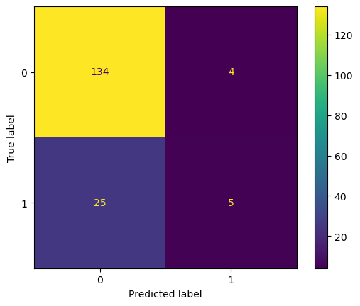

```python
plot_confusion_matrix(knn, xtest, ytest)
```

```
<sklearn.metrics._plot.roc_curve.RocCurveDisplay at 0x1fec0deee60>
```

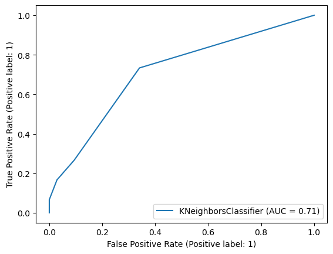

```python
plot_roc_curve(knn, xtest, ytest)
```

### 4) KNN Classifier after SMOTE

```python
knn2 = KNeighborsClassifier()
```

```python
knn2.fit(xtrain_smote, ytrain_smote)
```

```
KNeighborsClassifier()
```

```python
y_pred_knn2 = knn2.predict(xtest)
```

```python
print(classification_report(ytest,y_pred_knn2))
```

```
              precision    recall  f1-score   support

           0       0.92      0.70      0.80       138
           1       0.34      0.70      0.46        30

    accuracy                           0.70       168
   macro avg       0.63      0.70      0.63       168
weighted avg       0.81      0.70      0.73       168
```

After applying SMOTE, the KNN model shows improvement in classifying instances of class 1 (attrition) with higher recall and F1-score compared to the model without SMOTE. However, precision for class 1 decreased, indicating more false positives. Overall, the model's performance seems to have improved in terms of balancing class distribution

```
<sklearn.metrics._plot.confusion_matrix.ConfusionMatrixDisplay at 0x1febfdabee0>
```

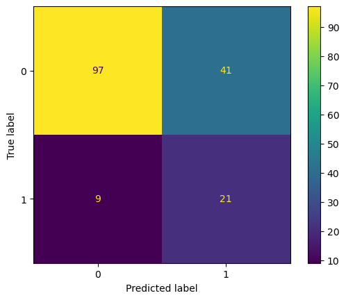

```python
plot_confusion_matrix(knn2, xtest, ytest)
```

```
<sklearn.metrics._plot.roc_curve.RocCurveDisplay at 0x1fec597d750>
```

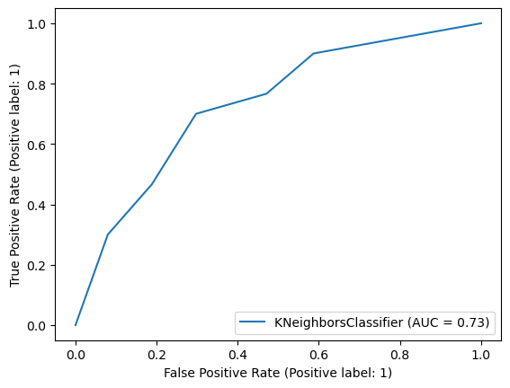

```python
plot_roc_curve(knn2, xtest, ytest)
```

Result:KNN After SMOTE has the highest recall for class 1 (attrition), indicating that it correctly identifies a higher proportion of actual attrition instances, although its precision is lower.

### 5) Random Forest Classifier

```python
from sklearn.ensemble import RandomForestClassifier
```

```python
rf = RandomForestClassifier(n_estimators=80,oob_score=True,random_state=40)
```

```python
rf.fit(xtrain_smote,ytrain_smote)
```

```
RandomForestClassifier(n_estimators=80, oob_score=True, random_state=40)
```

```python
rf.oob_score_
```

```
0.930783242258652
```

```python
#Parameter tuning
ls=[]
for w in range(20,300,10):
    clf=RandomForestClassifier(oob_score=True,n_estimators=w,random_state=400)
    clf.fit(xtrain_smote,ytrain_smote)
    oob=clf.oob_score_
    print('For n_estimators = ', w)
    print('OOB score is ', oob)
    print('************************')
    ls.append((oob,w))
```

```
For n_estimators =  20
OOB score is  0.8934426229508197
For n_estimators =  30
OOB score is  0.9171220400728597
For n_estimators =  40
OOB score is  0.9207650273224044
For n_estimators =  50
OOB score is  0.9289617486338798
For n_estimators =  60
OOB score is  0.9316939890710383
For n_estimators =  70
OOB score is  0.9271402550091075
For n_estimators =  80
OOB score is  0.9298724954462659
For n_estimators =  90
OOB score is  0.9298724954462659
For n_estimators =  100
OOB score is  0.9316939890710383
For n_estimators =  110
OOB score is  0.9344262295081968
For n_estimators =  120
OOB score is  0.9335154826958105
For n_estimators =  130
OOB score is  0.930783242258652
For n_estimators =  140
OOB score is  0.9289617486338798
For n_estimators =  150
OOB score is  0.9326047358834244
For n_estimators =  160
OOB score is  0.9335154826958105
For n_estimators =  170
OOB score is  0.936247723132969
For n_estimators =  180
OOB score is  0.9344262295081968
For n_estimators =  190
OOB score is  0.9344262295081968
For n_estimators =  200
OOB score is  0.9353369763205829
For n_estimators =  210
OOB score is  0.9371584699453552
For n_estimators =  220
OOB score is  0.9380692167577414
For n_estimators =  230
OOB score is  0.9371584699453552
For n_estimators =  240
OOB score is  0.9389799635701275
For n_estimators =  250
OOB score is  0.9389799635701275
For n_estimators =  260
OOB score is  0.9389799635701275
For n_estimators =  270
OOB score is  0.9389799635701275
For n_estimators =  280
OOB score is  0.9380692167577414
For n_estimators =  290
OOB score is  0.9389799635701275
```

```python
print(max(ls))
```

```
(0.9389799635701275, 290)
```

```python
clf=RandomForestClassifier(oob_score=True,n_estimators=290,random_state=40)
```

```python
clf.fit(xtrain_smote,ytrain_smote)
```

```
RandomForestClassifier(n_estimators=290, oob_score=True, random_state=40)
```

```python
clf.oob_score_
```

```
0.9335154826958105
```

```python
y_pred_rf = clf.predict(xtest)
```

```python
print(classification_report(ytest,y_pred_rf))
```

```
              precision    recall  f1-score   support

           0       0.85      0.97      0.91       138
           1       0.64      0.23      0.34        30

    accuracy                           0.84       168
   macro avg       0.74      0.60      0.62       168
weighted avg       0.81      0.84      0.81       168
```

Random Forest model performs well in predicting employees who stay, its performance in identifying employees who leave is relatively weaker, as indicated by the lower recall and F1-score for this class.

```
<sklearn.metrics._plot.confusion_matrix.ConfusionMatrixDisplay at 0x1fec1996e00>
```

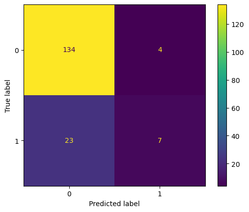

```python
plot_confusion_matrix(clf, xtest, ytest)
```

```
<sklearn.metrics._plot.roc_curve.RocCurveDisplay at 0x1fec4721030>
```

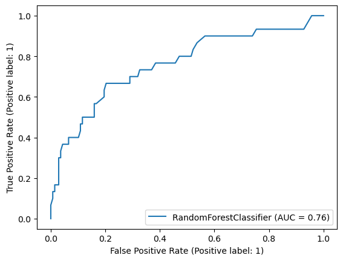

```python
plot_roc_curve(clf, xtest, ytest)
```

```python
importance_rf = clf.feature_importances_
```

```python
feature_imp_rf = pd.DataFrame({"Variable": features, "feature_importance": importance_rf } ).round(decimals=2).sort_values("feature_importance", ascending=False).style.bar(color=['red','green'])
```

```python
feature_imp_rf
```

|  | Variable | feature_importance |
| --- | --- | --- |
| 43 | OverTime_Yes | 0.100000 |
| 42 | MaritalStatus_Single | 0.050000 |
| 19 | YearsAtCompany | 0.050000 |
| 14 | RelationshipSatisfaction | 0.040000 |
| 21 | YearsSinceLastPromotion | 0.040000 |
| 20 | YearsInCurrentRole | 0.040000 |
| 8 | JobSatisfaction | 0.040000 |
| 9 | MonthlyIncome | 0.040000 |
| 17 | TrainingTimesLastYear | 0.040000 |
| 16 | TotalWorkingYears | 0.040000 |
| 15 | StockOptionLevel | 0.040000 |
| 1 | DailyRate | 0.030000 |
| 18 | WorkLifeBalance | 0.030000 |
| 0 | Age | 0.030000 |
| 22 | YearsWithCurrManager | 0.030000 |
| 2 | DistanceFromHome | 0.030000 |
| 11 | NumCompaniesWorked | 0.030000 |
| 10 | MonthlyRate | 0.030000 |
| 5 | HourlyRate | 0.030000 |
| 12 | PercentSalaryHike | 0.020000 |
| 41 | MaritalStatus_Married | 0.020000 |
| 3 | Education | 0.020000 |
| 4 | EnvironmentSatisfaction | 0.020000 |
| 6 | JobInvolvement | 0.020000 |
| 7 | JobLevel | 0.020000 |
| 31 | EducationField_Technical Degree | 0.010000 |
| 39 | JobRole_Sales Executive | 0.010000 |
| 38 | JobRole_Research Scientist | 0.010000 |
| 36 | JobRole_Manufacturing Director | 0.010000 |
| 34 | JobRole_Laboratory Technician | 0.010000 |
| 32 | Gender_Male | 0.010000 |
| 29 | EducationField_Medical | 0.010000 |
| 27 | EducationField_Life Sciences | 0.010000 |
| 26 | Department_Sales | 0.010000 |
| 25 | Department_Research & Development | 0.010000 |
| 24 | BusinessTravel_Travel_Rarely | 0.010000 |
| 23 | BusinessTravel_Travel_Frequently | 0.010000 |
| 30 | EducationField_Other | 0.000000 |
| 33 | JobRole_Human Resources | 0.000000 |
| 28 | EducationField_Marketing | 0.000000 |
| 35 | JobRole_Manager | 0.000000 |
| 37 | JobRole_Research Director | 0.000000 |
| 40 | JobRole_Sales Representative | 0.000000 |
| 13 | PerformanceRating | 0.000000 |